# Biking and Walking

Alejandra Gerosa

November 9, 2019

## Biking and Walking Tidy Tuesday

In this Tidy Tuesday experiment, I hope to: 1. Learn to scrape data off websites 2. Make a chart with a non-default look-and-feel

# Loading the data

```r
commute_mode <- readr::read_csv("https://raw.githubusercontent.com/rfordatascience/tidytuesday/master/data/2019/2019-11-05/commute.csv")
glimpse(commute_mode)
```

```
## Observations: 3,496
## Variables: 9
## $ city         <chr> "Aberdeen city", "Acworth city", "Addison village",…
## $ state        <chr> "South Dakota", "Georgia", "Illinois", "California"…
## $ city_size    <chr> "Small", "Small", "Small", "Small", "Small", "Small…
## $ mode         <chr> "Bike", "Bike", "Bike", "Bike", "Bike", "Bike", "Bi…
## $ n            <dbl> 110, 0, 43, 0, 121, 0, 84, 23, 0, 576, 35, 77, 419,…
## $ percent      <dbl> 0.8, 0.0, 0.2, 0.0, 1.5, 0.0, 0.8, 0.2, 0.0, 1.5, 0…
## $ moe          <dbl> 0.5, 0.4, 0.3, 0.5, 1.0, 0.2, 1.1, 0.3, 0.2, 0.4, 0…
## $ state_abb    <chr> "SD", "GA", "IL", "CA", "MI", "MA", "CA", "SC", "AL…
## $ state_region <chr> "North Central", "South", "North Central", "West", …
```

# Exploring and cleaning the data

```r
commute_mode_wider <- commute_mode %>%
  select(city, state, city_size, state_abb, state_region, mode, percent) %>%
  spread(mode, percent) %>%
  rename(bike = Bike,
         walk = Walk) %>%
  mutate(bike_walk = bike + walk)
```

```r
totalize_commutes <- function(commute_df) {
  summarize(commute_df,
            count = n(),
            num_cities = n_distinct(city),
            avg_bike = mean(bike, na.rm = TRUE),
            sd_bike = sd(bike, na.rm = TRUE),
            has_data_bike = sum(!is.na(bike)),
            avg_walk = mean(walk, na.rm = TRUE),
            sd_walk = sd(walk, na.rm = TRUE),
            has_data_walk = sum(!is.na(walk)),
            avg_bike_walk = mean(bike_walk, na.rm = TRUE),
            sd_bike_walk = sd(bike_walk, na.rm = TRUE),
            has_data_bike_walk = sum(!is.na(bike_walk))
  )
}

commute_mode_wider %>% group_by(city_size) %>%
  totalize_commutes()
```

```
## # A tibble: 3 x 12
##   city_size count num_cities avg_bike sd_bike has_data_bike avg_walk
##   <chr>     <int>      <int>    <dbl>   <dbl>         <int>    <dbl>
## 1 Large       109        109    0.952    1.04           109     3.44
## 2 Medium      176        171    0.880    1.50           176     3.01
## 3 Small      1465       1352    0.632    1.16          1463     2.85
## # … with 5 more variables: sd_walk <dbl>, has_data_walk <int>,
## #   avg_bike_walk <dbl>, sd_bike_walk <dbl>, has_data_bike_walk <int>
```

```r
commute_mode_wider %>% group_by(city) %>%
  totalize_commutes() %>% arrange(desc(count))
```

```
## # A tibble: 1,579 x 12
##    city  count num_cities avg_bike sd_bike has_data_bike avg_walk sd_walk
##    <chr> <int>      <int>    <dbl>   <dbl>         <int>    <dbl>   <dbl>
##  1 Colu…     5          1    0.4     0.245             5     2.44   1.46
##  2 Spri…     5          1    0.76    0.856             5     3.4    0.834
##  3 Aubu…     4          1    0.8     0.804             4     4.08   1.70
##  4 Gree…     4          1    0.2     0.183             4     3.5    1.91
##  5 Lafa…     4          1    0.725   0.310             4     1.98   0.499
##  6 Lake…     4          1    0.625   0.126             4     2.4    0.887
##  7 Lanc…     4          1    0.275   0.359             4     3.9    4.81
##  8 Newa…     4          1    0.9     1.01              4     6.12   6.22
##  9 Rich…     4          1    1.25    0.874             4     3.8    1.53
## 10 Alba…     3          1    0.833   0.503             3     5.87   3.50
## # … with 1,569 more rows, and 4 more variables: has_data_walk <int>,
## #   avg_bike_walk <dbl>, sd_bike_walk <dbl>, has_data_bike_walk <int>
```

```r
commute_mode_wider %>% group_by(city, state) %>%
  totalize_commutes() %>% arrange(desc(count), city)
```

```
## # A tibble: 1,750 x 13
## # Groups:   city [1,579]
##    city  state count num_cities avg_bike sd_bike has_data_bike avg_walk
##    <chr> <chr> <int>      <int>    <dbl>   <dbl>         <int>    <dbl>
##  1 Aber… Sout…     1          1      0.8      NA             1      4.4
##  2 Abil… Texas     1          1      0.4      NA             1      3.2
##  3 Acwo… Geor…     1          1      0        NA             1      1.1
##  4 Addi… Illi…     1          1      0.2      NA             1      0.8
##  5 Adel… Cali…     1          1      0        NA             1      0.5
##  6 Adri… Mich…     1          1      1.5      NA             1     11.8
##  7 Agaw… Mass…     1          1      0        NA             1      1.6
##  8 Agou… Cali…     1          1      0.8      NA             1      2.2
##  9 Aike… Sout…     1          1      0.2      NA             1      2.7
## 10 Akro… Ohio      1          1      0.2      NA             1      2.8
## # … with 1,740 more rows, and 5 more variables: sd_walk <dbl>,
## #   has_data_walk <int>, avg_bike_walk <dbl>, sd_bike_walk <dbl>,
## #   has_data_bike_walk <int>
```

```r
commute_mode_wider %>% group_by(state) %>%
  totalize_commutes() %>% arrange(num_cities)
```

```
## # A tibble: 53 x 12
##    state count num_cities avg_bike sd_bike has_data_bike avg_walk sd_walk
##    <chr> <int>      <int>    <dbl>   <dbl>         <int>    <dbl>   <dbl>
##  1 Ca        1          1    0.5    NA                 1   NaN      NA
##  2 Dist…     1          1    3.1    NA                 1    12.1    NA
##  3 Hawa…     1          1    1.8    NA                 1     9      NA
##  4 Mass…     1          1    0.2    NA                 1   NaN      NA
##  5 Verm…     1          1    5      NA                 1    20.3    NA
##  6 Alas…     3          3    1.43    0.416             3     5.03    2.77
##  7 Dela…     3          3    0.933   1.27              3     8.53    4.98
##  8 Nort…     5          5    0.78    0.466             5     2.86    1.36
##  9 Sout…     5          5    1.2     1.41              5     3.7     3.19
## 10 West…     5          5    0.48    0.356             5     7.88    5.94
## # … with 43 more rows, and 4 more variables: has_data_walk <int>,
## #   avg_bike_walk <dbl>, sd_bike_walk <dbl>, has_data_bike_walk <int>
```

There’s two issues I will want to fix here, and arranging by num_cities allowed me to more easily identify them: 1. There are different cities that have the same name. They are in different sttates, so I’ll create a new variable that also includes the state, so that I can easily identify each observation. 2. I seem to have 53 states. This is because two state names are misspelled in the originla dataframe. I’ll fix these. Also I’ll add a state abbreviation and region for Washington DC. So I’ll redo the earlier steps to account for these issues.

```r
commute_mode %>% filter(state == "Ca")
```

```
## # A tibble: 1 x 9
##   city     state city_size mode      n percent   moe state_abb state_region
##   <chr>    <chr> <chr>     <chr> <dbl>   <dbl> <dbl> <chr>     <chr>
## 1 El Paso… Ca    Small     Bike     71     0.5   0.4 <NA>      <NA>
```

```r
commute_mode %>% filter(grepl("Paso", city))
```

```
## # A tibble: 4 x 9
##   city     state city_size mode      n percent   moe state_abb state_region
##   <chr>    <chr> <chr>     <chr> <dbl>   <dbl> <dbl> <chr>     <chr>
## 1 El Paso… Ca    Small     Bike     71     0.5   0.4 <NA>      <NA>
## 2 El Paso… Texas Large     Bike    413     0.2   0.1 TX        South
## 3 El Paso… Cali… Small     Walk    203     1.6   0.8 CA        West
## 4 El Paso… Texas Large     Walk   5175     1.9   0.2 TX        South
```

```r
commute_mode[commute_mode$state == "Ca",] <- filter(commute_mode, state %in% c("Ca"))  %>%
  mutate(state = "California",
         state_abb = "CA",
         state_region = "West")

commute_mode %>% filter(state == "Massachusett")
```

```
## # A tibble: 1 x 9
##   city     state city_size mode      n percent   moe state_abb state_region
##   <chr>    <chr> <chr>     <chr> <dbl>   <dbl> <dbl> <chr>     <chr>
## 1 West Sp… Mass… Small     Bike     23     0.2   0.2 <NA>      <NA>
```

```r
commute_mode %>% filter(grepl("West Springfield", city))
```

```
## # A tibble: 2 x 9
##   city     state city_size mode      n percent   moe state_abb state_region
##   <chr>    <chr> <chr>     <chr> <dbl>   <dbl> <dbl> <chr>     <chr>
## 1 West Sp… Mass… Small     Bike     23     0.2   0.2 <NA>      <NA>
## 2 West Sp… Mass… Small     Walk    286     2.1   1.2 MA        Northeast
```

```r
commute_mode[commute_mode$state == "Massachusett",] <- filter(commute_mode, state == "Massachusett")  %>%
  mutate(state = "Massachusetts",
         state_abb = "MA",
         state_region = "Northeast")

commute_mode[commute_mode$state == "District of Columbia",] <- filter(commute_mode, state == "District of Columbia")  %>%
  mutate(state_abb = "DC",
         state_region = "Northeast")


summary(commute_mode)
```

```
##      city              state            city_size
##  Length:3496        Length:3496        Length:3496
##  Class :character   Class :character   Class :character
##  Mode  :character   Mode  :character   Mode  :character
##
##
##
##      mode                 n               percent            moe
##  Length:3496        Min.   :     0.0   Min.   : 0.000   Min.   :0.1000
##  Class :character   1st Qu.:    59.0   1st Qu.: 0.300   1st Qu.:0.3000
##  Mode  :character   Median :   190.0   Median : 0.900   Median :0.5000
##                     Mean   :   847.9   Mean   : 1.789   Mean   :0.5944
##                     3rd Qu.:   529.0   3rd Qu.: 2.100   3rd Qu.:0.8000
##                     Max.   :378352.0   Max.   :42.400   Max.   :5.4000
##   state_abb         state_region
##  Length:3496        Length:3496
##  Class :character   Class :character
##  Mode  :character   Mode  :character
##
##
##
```

```r
commute_mode_wider <- commute_mode %>%
  mutate(city_state = paste(city, state_abb)) %>%
  select(city_state, state, city_size, state_abb, state_region, mode, percent) %>%
  spread(mode, percent) %>%
  rename(bike = Bike,
         walk = Walk) %>%
  mutate(bike_walk = bike + walk)


totalize_commutes <- function(commute_df) {
  summarize(commute_df,
            num_cities = n_distinct(city_state),
            avg_bike = mean(bike, na.rm = TRUE),
            sd_bike = sd(bike, na.rm = TRUE),
            avg_walk = mean(walk, na.rm = TRUE),
            sd_walk = sd(walk, na.rm = TRUE),
            avg_bike_walk = mean(bike_walk, na.rm = TRUE),
            sd_bike_walk = sd(bike_walk, na.rm = TRUE)
  )
}

commute_mode_wider %>% group_by(city_size) %>%
  totalize_commutes()
```

```
## # A tibble: 3 x 8
##   city_size num_cities avg_bike sd_bike avg_walk sd_walk avg_bike_walk
##   <chr>          <int>    <dbl>   <dbl>    <dbl>   <dbl>         <dbl>
## 1 Large            109    0.952    1.04     3.44    2.69          4.39
## 2 Medium           176    0.880    1.50     3.01    3.12          3.89
## 3 Small           1463    0.632    1.16     2.85    3.58          3.48
## # … with 1 more variable: sd_bike_walk <dbl>
```

```r
commute_mode_wider %>% group_by(state) %>%
  totalize_commutes() %>% arrange(num_cities)
```

```
## # A tibble: 51 x 8
##    state num_cities avg_bike sd_bike avg_walk sd_walk avg_bike_walk
##    <chr>      <int>    <dbl>   <dbl>    <dbl>   <dbl>         <dbl>
##  1 Dist…          1    3.1    NA        12.1    NA            15.2
##  2 Hawa…          1    1.8    NA         9      NA            10.8
##  3 Verm…          1    5      NA        20.3    NA            25.3
##  4 Alas…          3    1.43    0.416     5.03    2.77          6.47
##  5 Dela…          3    0.933   1.27      8.53    4.98          9.47
##  6 Nort…          5    0.78    0.466     2.86    1.36          3.64
##  7 Sout…          5    1.2     1.41      3.7     3.19          4.9
##  8 West…          5    0.48    0.356     7.88    5.94          8.36
##  9 Wyom…          5    1.7     2.86      3.38    3.27          5.08
## 10 Maine          6    0.817   0.564     6.5     3.60          7.32
## # … with 41 more rows, and 1 more variable: sd_bike_walk <dbl>
```

# Additional information

I want to add to the dataset the actual size (population) of each city. That infomation is readily available on Wikipedia’s [List of United States Cities by Population](https://en.wikipedia.org/wiki/List_of_United_States_cities_by_population) page, so I’ll scrape it from there. It’s only available for cities with a population of at least 100,000, so that will have to do for now.

```r
wikipage <- read_html("https://en.wikipedia.org/wiki/List_of_United_States_cities_by_population")

additional_information <- wikipage %>%
  html_node(xpath='//*[@id="mw-content-text"]/div/table[5]') %>%
  html_table(fill=TRUE)
```

There’s a lot I would need to clean up here, but for now I’ll focus on the information I need. I’ll use the population figures from the 2010 census, since the commute data is from a 2008-2012 timeframe.

```r
additional_information$`2010Census` <- as.numeric(gsub(",", "", additional_information$`2010Census`))
cities_population <- additional_information[,1:5] %>%
  select(city = City, state = `State[c]`, population = `2010Census`)
cities_population <- as_tibble(cities_population)
```

Now I need to make the names on this dataframe list match the names on the original dataframe. There are some automatic fixes that will get me most of the way there, but for 11 cities there are inconsistencies that I ended up fixing manually (🤷).

```r
cities_population$city <- cities_population$city %>%
  str_remove("\\[.*")

cities_population <- cities_population %>%
  inner_join(unique(select(commute_mode_wider, state, state_abb))) %>%
  mutate(name_city_state = paste(city, "city", state_abb))
cities_population <- cities_population %>%
  mutate(matches_commute_city = cities_population$name_city_state %in% commute_mode_wider$city_state)
sum(!cities_population$matches_commute_city)
```

```
## [1] 19
```

```r
cities_population[cities_population$city == "Indianapolis",] <- cities_population %>%
  filter(city == "Indianapolis") %>%
  mutate(name_city_state = "Indianapolis city (balance) IN")
cities_population <- cities_population %>%
  mutate(matches_commute_city = cities_population$name_city_state %in% commute_mode_wider$city_state)
sum(!cities_population$matches_commute_city)
```

```
## [1] 18
```

```r
cities_population[cities_population$city == "Honolulu",] <- cities_population %>%
  filter(city == "Honolulu") %>%
  mutate(name_city_state = "Urban Honolulu CDP HI")
cities_population <- cities_population %>%
  mutate(matches_commute_city = cities_population$name_city_state %in% commute_mode_wider$city_state)
sum(!cities_population$matches_commute_city)
```

```
## [1] 17
```

```r
cities_population[cities_population$city == "Lexington",] <- cities_population %>%
  filter(city == "Lexington") %>%
  mutate(name_city_state = "Lexington-Fayette urban county KY")
cities_population <- cities_population %>%
  mutate(matches_commute_city = cities_population$name_city_state %in% commute_mode_wider$city_state)
sum(!cities_population$matches_commute_city)
```

```
## [1] 16
```

```r
cities_population[cities_population$city == "Saint Paul",] <- cities_population %>%
  filter(city == "Saint Paul") %>%
  mutate(name_city_state = "St. Paul city MN")
cities_population <- cities_population %>%
  mutate(matches_commute_city = cities_population$name_city_state %in% commute_mode_wider$city_state)
sum(!cities_population$matches_commute_city)
```

```
## [1] 15
```

```r
cities_population[cities_population$city == "Anchorage",] <- cities_population %>%
  filter(city == "Anchorage") %>%
  mutate(name_city_state = "Anchorage municipality AK")
cities_population <- cities_population %>%
  mutate(matches_commute_city = cities_population$name_city_state %in% commute_mode_wider$city_state)
sum(!cities_population$matches_commute_city)
```

```
## [1] 14
```

```r
cities_population[cities_population$city == "Gilbert",] <- cities_population %>%
  filter(city == "Gilbert") %>%
  mutate(name_city_state = "Gilbert town AZ")
cities_population <- cities_population %>%
  mutate(matches_commute_city = cities_population$name_city_state %in% commute_mode_wider$city_state)
sum(!cities_population$matches_commute_city)
```

```
## [1] 13
```

```r
cities_population[cities_population$city == "Winston–Salem",] <- cities_population %>%
  filter(city == "Winston–Salem") %>%
  mutate(name_city_state = "Winston-Salem city NC")
cities_population <- cities_population %>%
  mutate(matches_commute_city = cities_population$name_city_state %in% commute_mode_wider$city_state)
sum(!cities_population$matches_commute_city)
```

```
## [1] 12
```

```r
cities_population[cities_population$city == "Boise",] <- cities_population %>%
  filter(city == "Boise") %>%
  mutate(name_city_state = "Boise City city ID")
cities_population <- cities_population %>%
  mutate(matches_commute_city = cities_population$name_city_state %in% commute_mode_wider$city_state)
sum(!cities_population$matches_commute_city)
```

```
## [1] 11
```

```r
cities_population[cities_population$city == "Cary",] <- cities_population %>%
  filter(city == "Cary") %>%
  mutate(name_city_state = "Cary town NC")
cities_population <- cities_population %>%
  mutate(matches_commute_city = cities_population$name_city_state %in% commute_mode_wider$city_state)
sum(!cities_population$matches_commute_city)
```

```
## [1] 10
```

```r
cities_population[cities_population$city == "Ventura",] <- cities_population %>%
  filter(city == "Ventura") %>%
  mutate(name_city_state = "San Buenaventura (Ventura) city CA")
cities_population <- cities_population %>%
  mutate(matches_commute_city = cities_population$name_city_state %in% commute_mode_wider$city_state)
sum(!cities_population$matches_commute_city)
```

```
## [1] 9
```

```r
cities_population[cities_population$city == "Davie",] <- cities_population %>%
  filter(city == "Davie") %>%
  mutate(name_city_state = "Davie town FL")
cities_population <- cities_population %>%
  mutate(matches_commute_city = cities_population$name_city_state %in% commute_mode_wider$city_state)
sum(!cities_population$matches_commute_city)
```

```
## [1] 8
```

I am finally ready to add the population information to my commute modes dataframe. Cities in the commute dataframe with populations of more than 100,000 should now have a population number.

```r
commute_wide_pop <- left_join(
  commute_mode_wider,
  select(cities_population, name_city_state, population),
  by = c("city_state" = "name_city_state")
)

commute_wide_pop %>% group_by(city_size) %>%
  summarize(pop_missing = sum(is.na(population)))
```

```
## # A tibble: 3 x 2
##   city_size pop_missing
##   <chr>           <int>
## 1 Large               0
## 2 Medium              2
## 3 Small            1440
```

```r
filter(commute_wide_pop, city_size == "Medium" & is.na(population))
```

```
## # A tibble: 2 x 9
##   city_state state city_size state_abb state_region  bike  walk bike_walk
##   <chr>      <chr> <chr>     <chr>     <chr>        <dbl> <dbl>     <dbl>
## 1 Erie city… Penn… Medium    PA        Northeast      0.6   4.9       5.5
## 2 Flint cit… Mich… Medium    MI        North Centr…   0.2   2.6       2.8
## # … with 1 more variable: population <dbl>
```

```r
filter(commute_wide_pop, city_size == "Small" & !is.na(population))
```

```
## # A tibble: 23 x 9
##    city_state state city_size state_abb state_region  bike  walk bike_walk
##    <chr>      <chr> <chr>     <chr>     <chr>        <dbl> <dbl>     <dbl>
##  1 Allen cit… Texas Small     TX        South          0     0.6       0.6
##  2 Clovis ci… Cali… Small     CA        West           0.4   1.4       1.8
##  3 College S… Texas Small     TX        South          2.6   5.5       8.1
##  4 Davie tow… Flor… Small     FL        South          0.5   1.1       1.6
##  5 Greeley c… Colo… Small     CO        West           1.8   3.4       5.2
##  6 Hillsboro… Oreg… Small     OR        West           1.3   3.2       4.5
##  7 Jurupa Va… Cali… Small     CA        West           0.2   1.5       1.7
##  8 Lakeland … Flor… Small     FL        South          0.5   2.2       2.7
##  9 League Ci… Texas Small     TX        South          0.2   0.5       0.7
## 10 Lewisvill… Texas Small     TX        South          0.6   0.9       1.5
## # … with 13 more rows, and 1 more variable: population <dbl>
```

Two Medium sized cities are missing and ~20 small cities do have the population numbers. This is likely due to differences from the 2010 data and the 2018 projections (which are used to set the 100,000 theshold from the Wikipedia page).

# Visualize

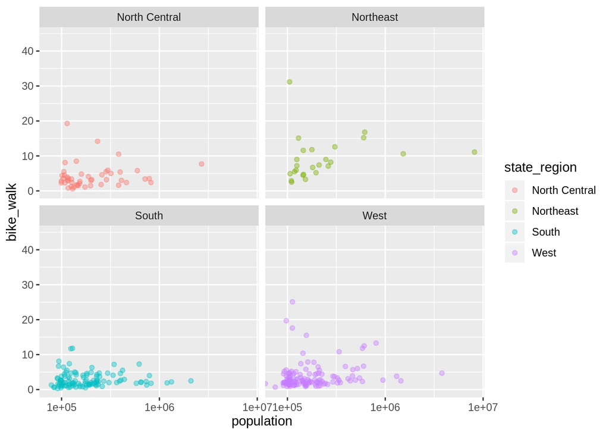

```r
commute_wide_pop %>%
  ggplot(aes(x = population, y = bike_walk, color = state_region)) +
  geom_point(alpha = 0.4) +
  scale_x_log10() +
  facet_wrap(~state_region)
```

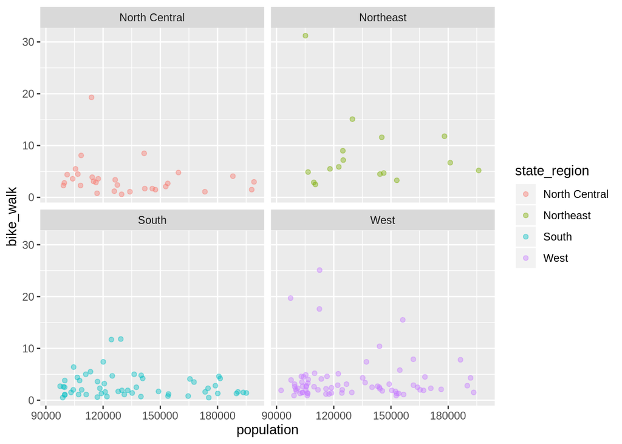

```r
commute_wide_pop %>%
  filter(city_size == "Medium") %>%
  ggplot(aes(x = population, y = bike_walk, color = state_region)) +
  geom_point(alpha = 0.4) +
  facet_wrap(~state_region)
```

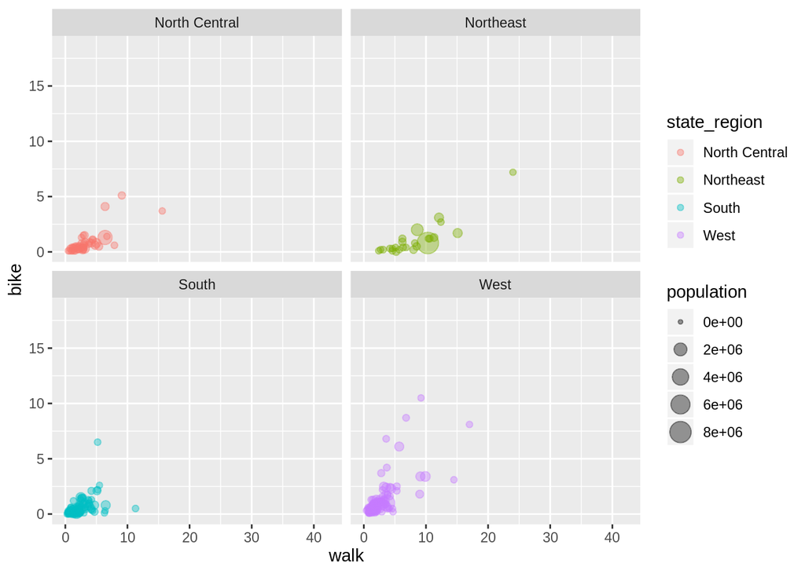

```r
commute_wide_pop %>%
  ggplot(aes(x = walk, y = bike, color = state_region, size = population)) +
  geom_point(alpha = 0.4) +
  facet_wrap(~state_region)
```

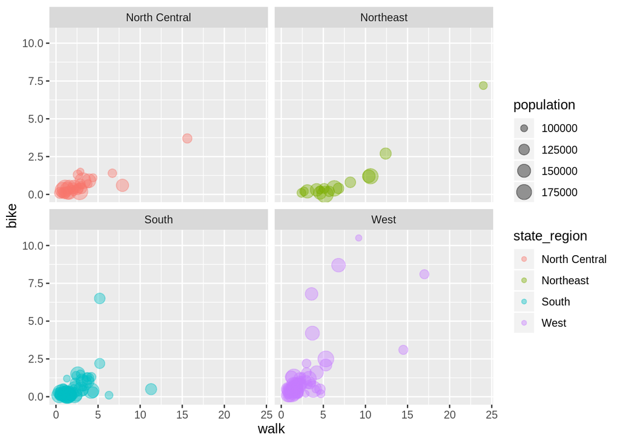

```r
commute_wide_pop %>%
  filter(city_size == "Medium") %>%
  ggplot(aes(x = walk, y = bike, color = state_region, size = population)) +
  geom_point(alpha = 0.4) +
  facet_wrap(~state_region)
```

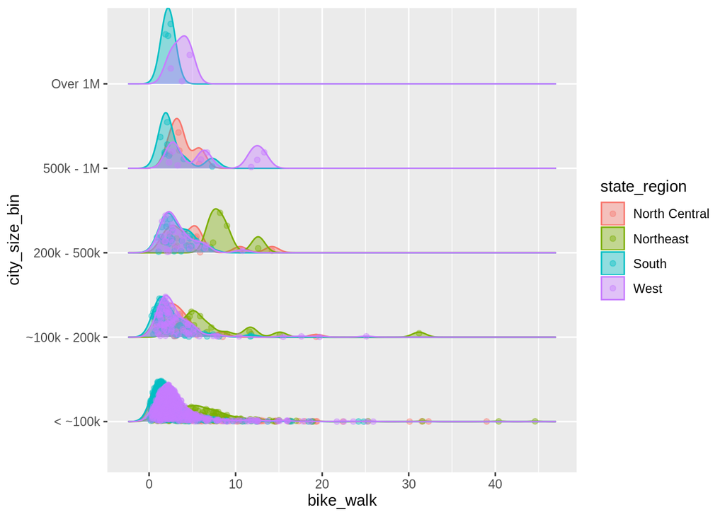

```r
commute_wide_pop %>%
  mutate(city_size_bin = case_when(
    population < 200000 ~ "~100k - 200k",
    population >= 200000 & population < 500000 ~ "200k - 500k",
    population >= 500000 & population < 1000000 ~ "500k - 1M",
    population >= 1000000 ~ "Over 1M",
    TRUE ~ "< ~100k"
  )) %>%
  ggplot(aes(x = bike_walk, y = city_size_bin, color = state_region, fill = state_region)) +
  geom_density_ridges(scale = 0.9, alpha = 0.4, jittered_points = TRUE)
```

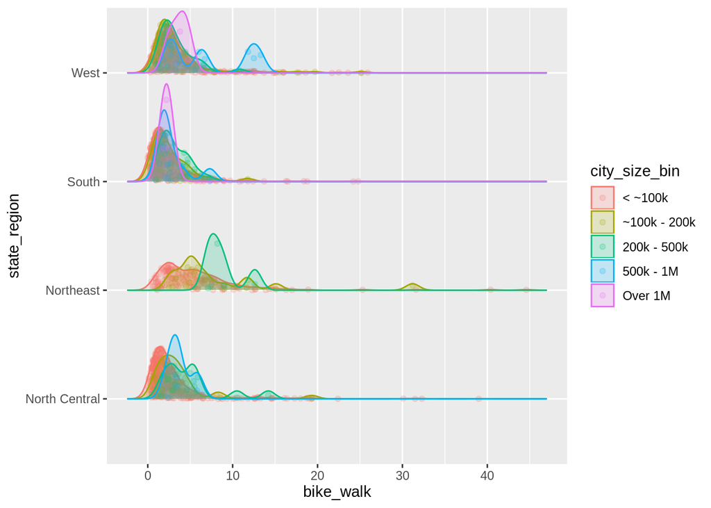

```r
commute_wide_pop %>%
  mutate(city_size_bin = case_when(
    population < 200000 ~ "~100k - 200k",
    population >= 200000 & population < 500000 ~ "200k - 500k",
    population >= 500000 & population < 1000000 ~ "500k - 1M",
    population >= 1000000 ~ "Over 1M",
    TRUE ~ "< ~100k"
  )) %>%
  ggplot(aes(x = bike_walk, y = state_region, fill = city_size_bin, color = city_size_bin)) +
  geom_density_ridges(scale = 0.9, alpha = 0.2, jittered_points = TRUE)
```

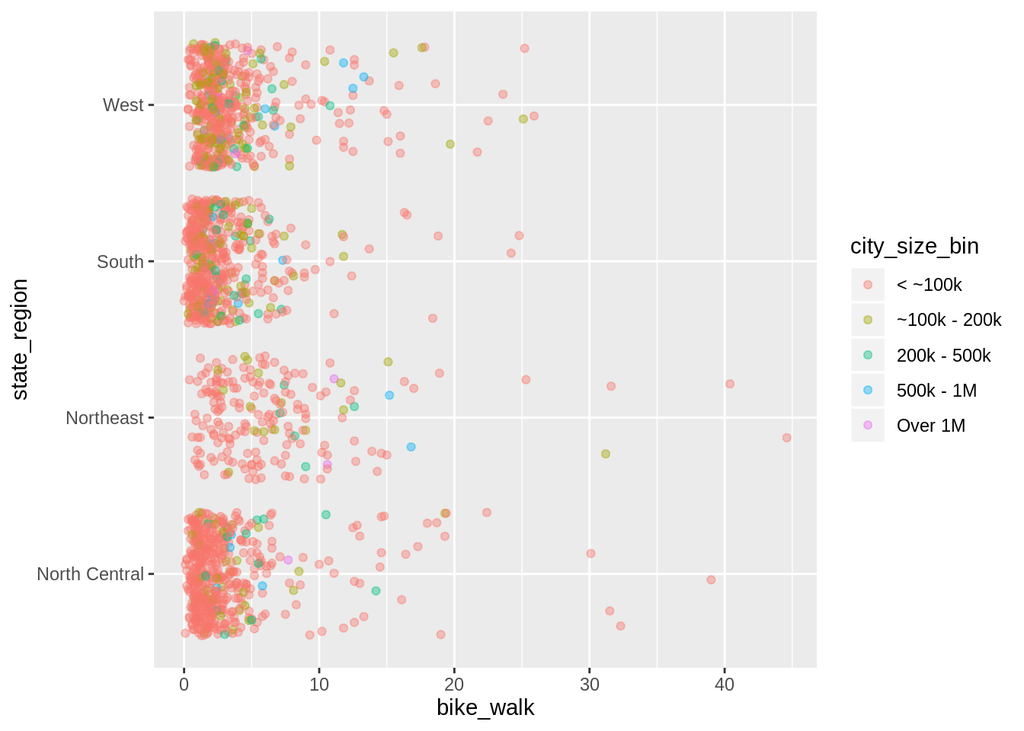

```r
commute_wide_pop %>%
  mutate(city_size_bin = case_when(
    population < 200000 ~ "~100k - 200k",
    population >= 200000 & population < 500000 ~ "200k - 500k",
    population >= 500000 & population < 1000000 ~ "500k - 1M",
    population >= 1000000 ~ "Over 1M",
    TRUE ~ "< ~100k"
  )) %>%
  ggplot(aes(x = bike_walk, y = state_region, fill = city_size_bin, color = city_size_bin)) +
  geom_jitter(alpha = 0.4)
```

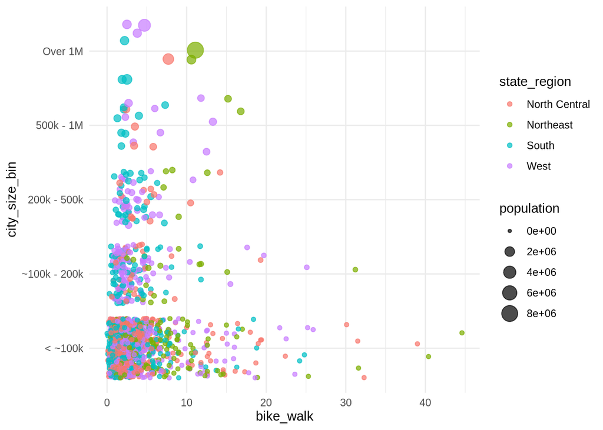

```r
commute_wide_pop %>%
  mutate(city_size_bin = case_when(
    population < 200000 ~ "~100k - 200k",
    population >= 200000 & population < 500000 ~ "200k - 500k",
    population >= 500000 & population < 1000000 ~ "500k - 1M",
    population >= 1000000 ~ "Over 1M",
    TRUE ~ "< ~100k"
  ),
  population = case_when(
    is.na(population) ~ 50000,
    TRUE ~ population
  )
  ) %>%
  ggplot(aes(x = bike_walk, y = city_size_bin, color = state_region, size = population)) +
  geom_jitter(alpha = .7) +
  theme_minimal()
```

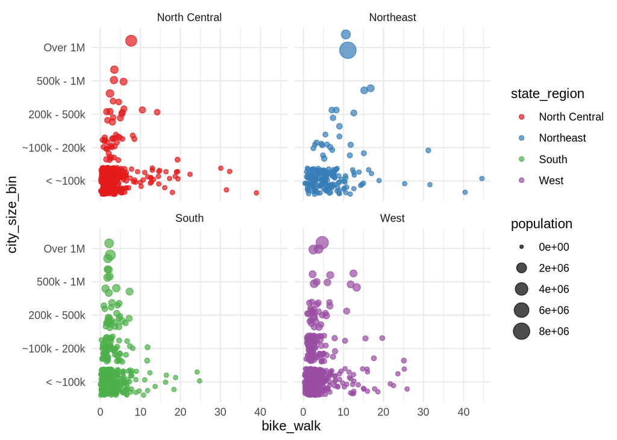

```r
commute_wide_pop %>%
  mutate(
    city_size_bin = case_when(
      population < 200000 ~ "~100k - 200k",
      population >= 200000 & population < 500000 ~ "200k - 500k",
      population >= 500000 & population < 1000000 ~ "500k - 1M",
      population >= 1000000 ~ "Over 1M",
      TRUE ~ "< ~100k"
      ),
    population = case_when(
      is.na(population) ~ 50000,
      TRUE ~ population
      )
    ) %>%
  ggplot(aes(x = bike_walk, y = city_size_bin, color = state_region, size = population)) +
  geom_jitter(alpha = .7) +
  theme_minimal() +
  scale_color_brewer(palette = "Set1") +
  facet_wrap(~state_region)
```

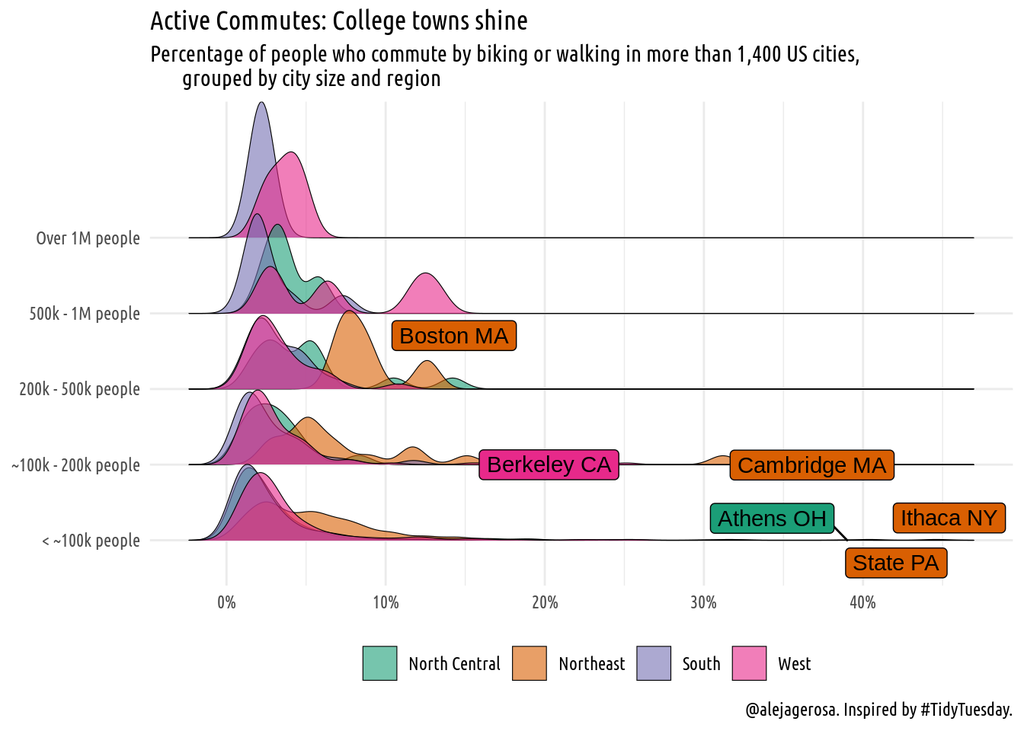

```r
commute_chart_data <- commute_wide_pop %>%
  mutate(
    city_size_bin = case_when(
      population < 200000 ~ "~100k - 200k",
      population >= 200000 & population < 500000 ~ "200k - 500k",
      population >= 500000 & population < 1000000 ~ "500k - 1M",
      population >= 1000000 ~ "Over 1M",
      TRUE ~ "< ~100k"
      ),
    population = case_when(
      is.na(population) ~ 50000,
      TRUE ~ population
      )
    )
commute_chart_data %>%
  ggplot(aes(x = bike_walk, y = city_size_bin, fill = state_region, label = paste(word(city_state, 1), word(city_state, -1)))) +
  geom_density_ridges(alpha = .6, size = 0.2, jittered_points = FALSE) +
  geom_label_repel(data = filter(commute_chart_data,
                                (bike_walk > 33 & city_size_bin == "< ~100k")|
                                  (bike_walk > 25 & city_size_bin == "~100k - 200k") |
                                  (bike_walk > 16 & city_size_bin == "500k - 1M")),
                   force = 1.5,
                   show_guide = FALSE) +
  theme_minimal(base_family = "Ubuntu Condensed") +
  theme(legend.position = "bottom") +
  scale_x_continuous(labels = function(x) paste0(x, "%")) +
  scale_y_discrete(labels = function(x) paste0(x, " people")) +
  scale_fill_brewer(palette = "Dark2") +
  labs(y = NULL,
       x = NULL,
       title = "Active Commutes: College towns shine",
       subtitle = "Percentage of people who commute by biking or walking in more than 1,400 US cities,
       grouped by city size and region",
       caption = "@alejagerosa. Inspired by #TidyTuesday.",
       fill = NULL)
```

```r
ggsave("bike_and_walk.jpg", last_plot())
```